# My hint: Seaborn palettes and colors

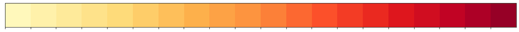

```python
sns.palplot(sns.color_palette("YlOrRd", 20))
```

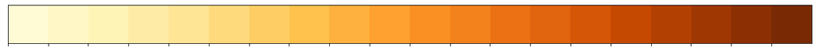

```python
sns.palplot(sns.color_palette("YlOrBr", 20))
```

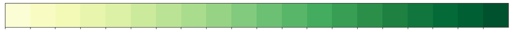

```python
sns.palplot(sns.color_palette("YlGn", 20))
```

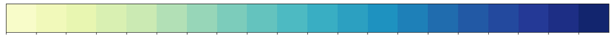

```python
sns.palplot(sns.color_palette("YlGnBu", 20))
```

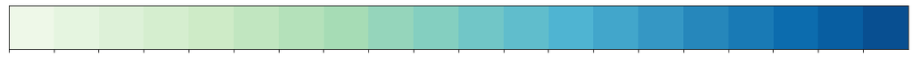

```python
sns.palplot(sns.color_palette("GnBu", 20))
```

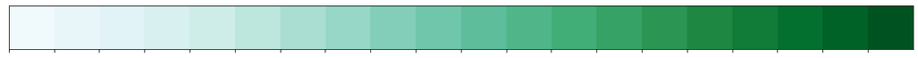

```python
sns.palplot(sns.color_palette("BuGn", 20))
```

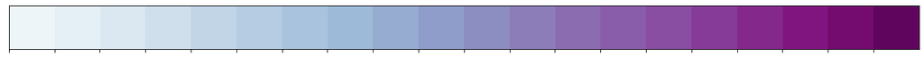

```python
sns.palplot(sns.color_palette("BuPu", 20))
```

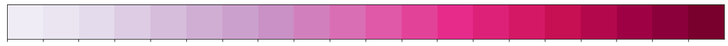

```python
sns.palplot(sns.color_palette("PuRd", 20))
```

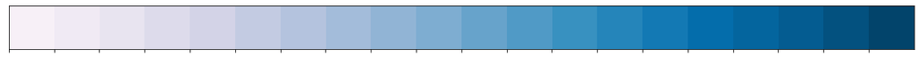

```python
sns.palplot(sns.color_palette("PuBu", 20))
```

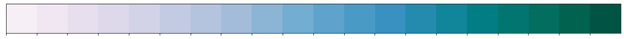

```python
sns.palplot(sns.color_palette("PuBuGn", 20))
```

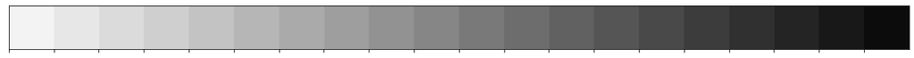

```python
sns.palplot(sns.color_palette("binary", 20))
```

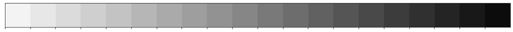

```python
sns.palplot(sns.color_palette("gist_yarg", 20))
```

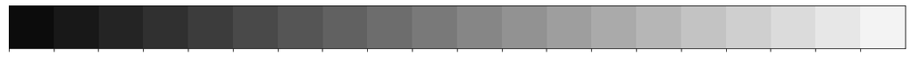

```python
sns.palplot(sns.color_palette("gray", 20))
```

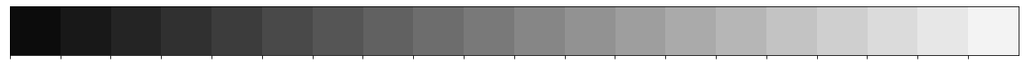

```python
sns.palplot(sns.color_palette("gist_gray", 20))
```

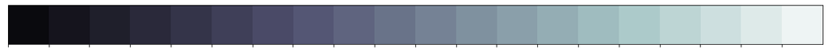

```python
sns.palplot(sns.color_palette("bone", 20))
```

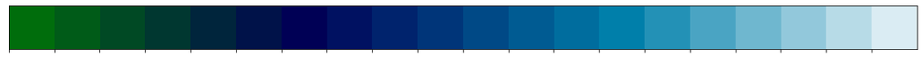

```python
sns.palplot(sns.color_palette("ocean", 20))
```

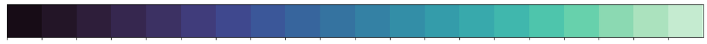

```python
sns.palplot(sns.color_palette("mako", 20))
```

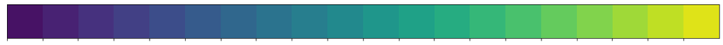

```python
sns.palplot(sns.color_palette("viridis", 20))
```

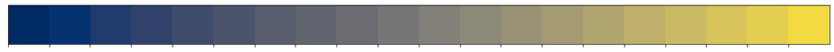

```python
sns.palplot(sns.color_palette("cividis", 20))
```

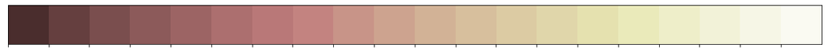

```python
sns.palplot(sns.color_palette("pink", 20))
```

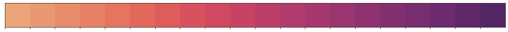

```python
sns.palplot(sns.color_palette("flare", 20))
```

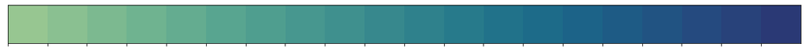

```python
sns.palplot(sns.color_palette("crest", 20))
```

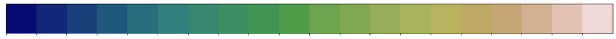

```python
sns.palplot(sns.color_palette("gist_earth", 20))
```

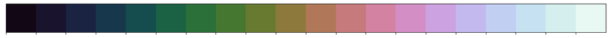

```python
sns.palplot(sns.color_palette("cubehelix", 20))
```

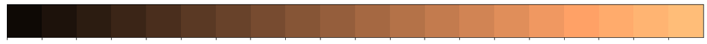

```python
sns.palplot(sns.color_palette("copper", 20))
```

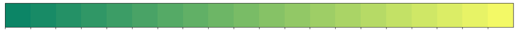

```python
sns.palplot(sns.color_palette("summer", 20))
```

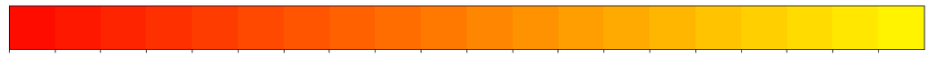

```python
sns.palplot(sns.color_palette("autumn", 20))
```

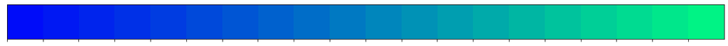

```python
sns.palplot(sns.color_palette("winter", 20))
```

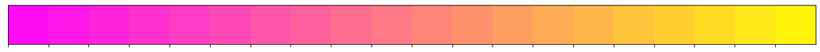

```python
sns.palplot(sns.color_palette("spring", 20))
```

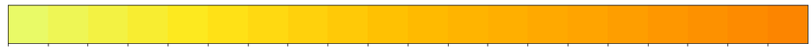

```python
sns.palplot(sns.color_palette("Wistia", 20))
```

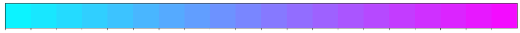

```python
sns.palplot(sns.color_palette("cool", 20))
```

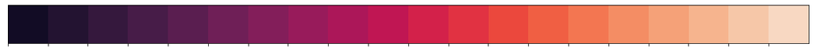

```python
sns.palplot(sns.color_palette("rocket", 20))
```

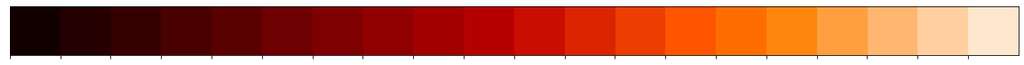

```python
sns.palplot(sns.color_palette("gist_heat", 20))
```

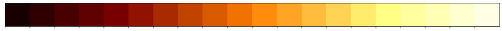

```python
sns.palplot(sns.color_palette("afmhot", 20))
```

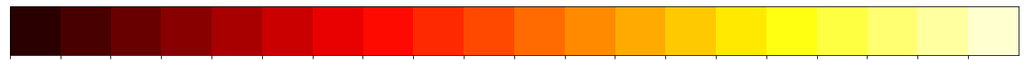

```python
sns.palplot(sns.color_palette("hot", 20))
```

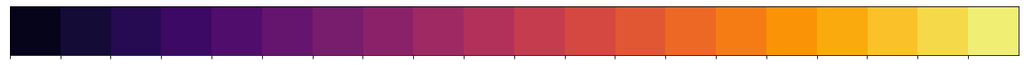

```python
sns.palplot(sns.color_palette("inferno", 20))
```

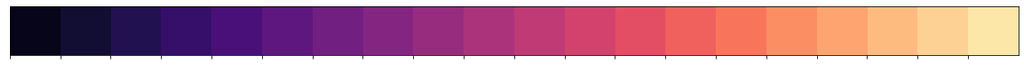

```python
sns.palplot(sns.color_palette("magma", 20))
```

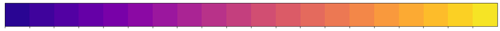

```python
sns.palplot(sns.color_palette("plasma", 20))
```

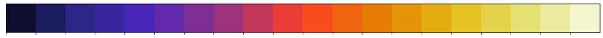

```python
sns.palplot(sns.color_palette("CMRmap", 20))
```

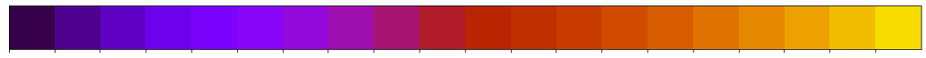

```python
sns.palplot(sns.color_palette("gnuplot", 20))
```

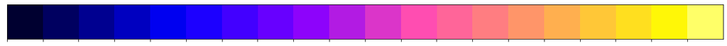

```python
sns.palplot(sns.color_palette("gnuplot2", 20))
```

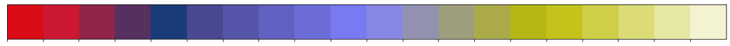

```python
sns.palplot(sns.color_palette("gist_stern", 20))
```

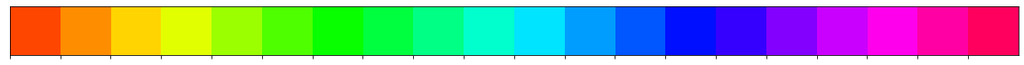

```python
sns.palplot(sns.color_palette("hsv", 20))
```

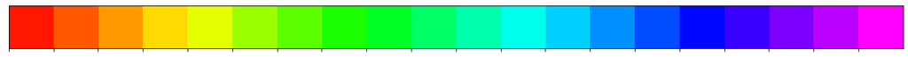

```python
sns.palplot(sns.color_palette("gist_rainbow", 20))
```

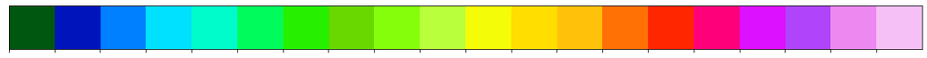

```python
sns.palplot(sns.color_palette("gist_ncar", 20))
```

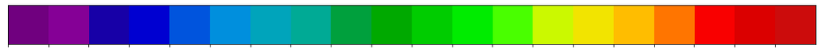

```python
sns.palplot(sns.color_palette("nipy_spectral", 20))
```

### Qualitative (категориальные)

Категориальные палитры лучше всего подходят для визуализации тяжелых элементов, таких как boxplot или violinplot. В этом случае необходимо просто различать элементы поэтому используются палитры из небольшого количества цветов.

Источник: [PyProg Управление цветом](https://pyprog.pro/sns/sns_12_color_setting.html)

Categorical palettes are best suited for rendering heavy elements such as boxplot or violinplot. In this case, it is simply necessary to distinguish the elements, so palettes of a small number of colors are used.

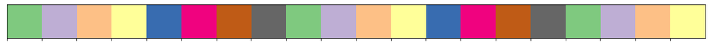

```python
sns.palplot(sns.color_palette("Accent", 20))
```

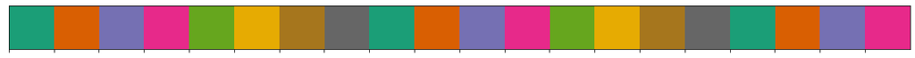

```python
sns.palplot(sns.color_palette("Dark2", 20))
```

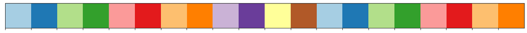

```python
sns.palplot(sns.color_palette("Paired", 20))
```

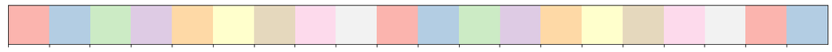

```python
sns.palplot(sns.color_palette("Pastel1", 20))
```

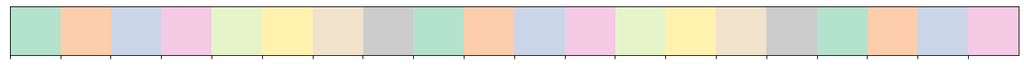

```python
sns.palplot(sns.color_palette("Pastel2", 20))
```

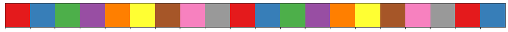

```python
sns.palplot(sns.color_palette("Set1", 20))
```

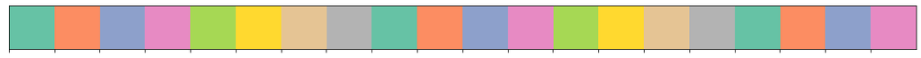

```python
sns.palplot(sns.color_palette("Set2", 20))
```

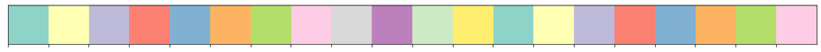

```python
sns.palplot(sns.color_palette("Set3", 20))
```

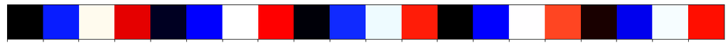

```python
sns.palplot(sns.color_palette("flag", 20))
```

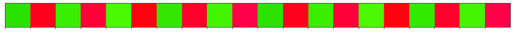

```python
sns.palplot(sns.color_palette("prism", 20))
```

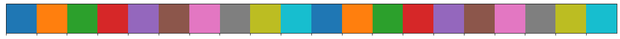

```python
sns.palplot(sns.color_palette("tab10", 20))
```

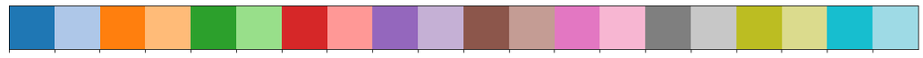

```python
sns.palplot(sns.color_palette("tab20", 20))
```

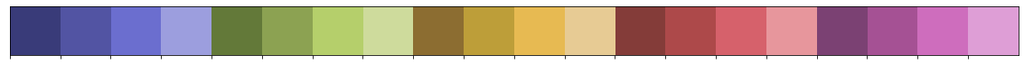

```python
sns.palplot(sns.color_palette("tab20b", 20))
```

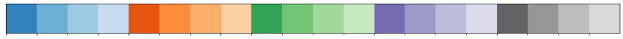

```python
sns.palplot(sns.color_palette("tab20c", 20))
```

## How to extract individual colors

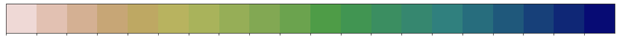

```python
sns.palplot(sns.color_palette("gist_earth_r", 20))
```

Например нам нужно 14 цветов, уберём из этих 20 первые 2 цвета (слишком бледные) и последние 4 (слишком тёмные). Выведем на экран значения цветов, скопируем их и создадим свою палитру, убрав лишнее:

For example, we need 14 colors, we will remove from these 20 the first 2 colors (too pale) and the last 4 (too dark). Let's display the color values on the screen, copy them and create our own palette, removing the excess:

```python
print(sns.color_palette("gist_earth_r", 20).as_hex())
```

```
['#f0dad7', '#e2c1b3', '#d5b194', '#c7a676', '#bea863', '#b9b35f', '#aab35c', '#96ae58', '#82a954', '#6ba44f', '#4e9c47', '#419552', '#3c8e61', '#368770', '#30817e', '#286d7d', '#20597b', '#184179', '#102777', '#080b75']
```

```python
my_palette=['#d5b194', '#c7a676', '#bea863', '#b9b35f', '#aab35c', '#96ae58', '#82a954',
            '#6ba44f', '#4e9c47', '#419552', '#3c8e61', '#368770', '#30817e', '#286d7d']
```

## Types of palettes

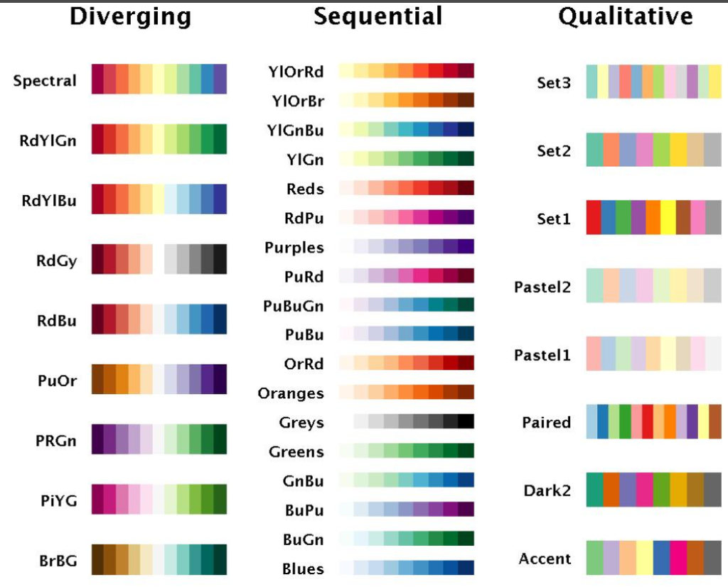

Условно цветовые палитры можно разделить на три категории:

- Diverging - расходящиеся палитры - подходят для визуализации числовых данных с категориальными границами;
- Sequential - последовательные палитры - используются для визуализации числовых данных;
- Qualitative - категориальные (или качественные) палитры - лучше всего подходят для визуализации категориальных данных.

[PyProg Управление цветом](https://pyprog.pro/sns/sns_12_color_setting.html)

Conventionally , color palettes can be divided into three categories:

- Diverging palettes - suitable for visualizing numerical data with categorical boundaries;
- Sequential palettes - are used to visualize numeric data;
- Qualitative or categorical palettes - are best suited for visualization of categorical data.